# Do Stats Make Competitive Pokemon?

[figure not shown]

Lotad is my favorite

# Preamble

This research focuses on something dear to most people under 30’s hearts: Pokemon. First and foremost, let’s talk about what exactly Pokemon is. Pokemon is a game, where you capture and battle with Pokemon, who come with an assortment of types, abilities, moves, and stats. Let’s look at an example of a Pokemon from our data:

```
## # A tibble: 1 × 15
##    ...1 dexno pokename Ability     hp   Atk   Def  SAtk  SDef   Spd generation
##   <dbl> <dbl> <chr>    <chr>    <dbl> <dbl> <dbl> <dbl> <dbl> <dbl>      <dbl>
## 1   270   245 Suicune  Pressure   100    75   115    90   115    85          2
## # … with 4 more variables: Rate <dbl>, Real <dbl>, bst <dbl>, genno <fct>
```

So, if we are looking only at stats of Pokemon, as we are, we would think that we would want the highest stats. If my Pokemon does more damage to yours, then I win. So, based off of that, we would think that the best players would use the strongest Pokemon, right? I used [Smogon’s Usage Statistics](https://www.smogon.com/stats/), which detail which Pokemon competitive Pokemon players use. Sadly, the highest strongest Pokemon stats wise was not the most used. So, here’s our research questions.

For our second question, we finally get to what the usage data is. The usage rates are for “OU” (overused) Pokemon, but that doesn’t really explain what’s going on. A Pokemon “starts” its journey in the OU tier, where then it’s usage in that tier decides which tier it actually ends up in. There are a bunch of tiers, but this research basically boils it down to untiered and OU. The tiering system was created to allow for weak Pokemon to be used competitively without being an absolute liability in the match. As such, we have a lot of Pokemon with very low usage, which causes us to have to use a nifty trick on the data in order for us to get an answer for our second question.

# Varaibles

We’ve already gone over most of the variables, so we’ll just cover the “meta” stats here, which refer to usage and transformations on base stats.

-bst: Base Stat Total. This is the additon of a Pokemon’s stats. Lotad’s bst, for instance, is 220, about half of the average bst. There’s no units on this.

-Rate: this is the usage rate. This cannot be over 100 because it is a percentage. For ease of reading, .2 is 20 percent, but here we will call 20 percent 20.

-Real: this is the number of battles a Pokemon has been brought to. It is a transformation of Rate.

-genno: this is the generation number, but as a factor. This was something I worked with and isn’t too helpful, since it is just generation as a factor.

# Each Generation’s bst Distribution

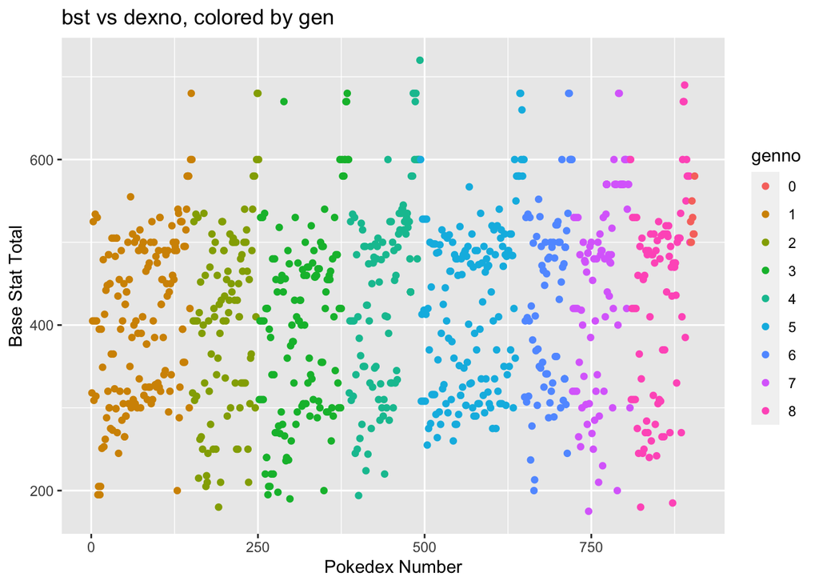

We can’t glean a whole bunch of information in this plot, but we can tell a few things here that we can’t in the next plot. First, we can see that some generations are “thin,” while others are not. Our points are colored by which generation they belong to. So, lets look at generation 1. It is pretty wide, about twice as wide as generation 7. The range of the points on the x axis relate to the number of Pokemon introduced. We see that generations 1 and 5 have the most Pokemon added, so we’ll remember to keep an eye on them for later. Next, we see that there are few Pokemon over 600 bst; those are legendary Pokemon, and often times they are banned from OU for being unfair, meaning they would have a very high usage rate. However, they aren’t *always* banned, so we won’t pay them any extra attention. There are also a few Pokemon at 600, who aren’t legendary but are strong, and they’ll be a big part of this project going forwards.

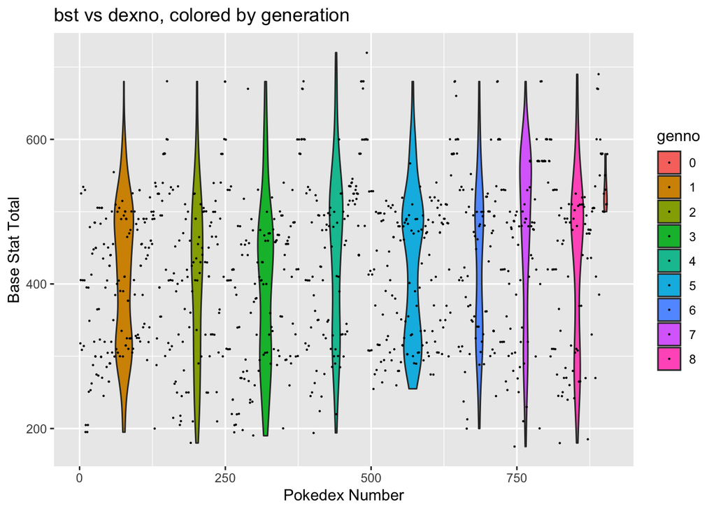

Here, we see a similar idea as the last, but in a violin plot (even the colors are the same!). This is a nice complementary plot because we get to see the distribution of strength in each generation and put that into conversation with the other generations. We can see a general trend, where the top is super skinny, the ~75th quartile being the widest part of the distribution, the ~50th quartile and the ~25th quartile being a little less wider, and then the bottom being skinny. These plots represent total number through, not percentage! Because of this it is kind of hard to compare them to each other, but we’ll manage. We see than gens 1 and 5 have some pretty similar distributions, except that gen 5 doesn’t go anywhere near as low as the rest of them! Interestingly enough, gen 5 is known as when excessive “power creep” began, which is where there are lots of strong Pokemon, so the weak ones get phased out of competitive play. We also see that generation 2 has a disproportionate amount of good Pokemon, and generation 7 takes that feeling to the next level. In Generation 6, the game started to recycle the bad Pokemon, for some reason. As such, they stopped making as many Pokemon with low bst. Look in the appendix for the actual distributions.

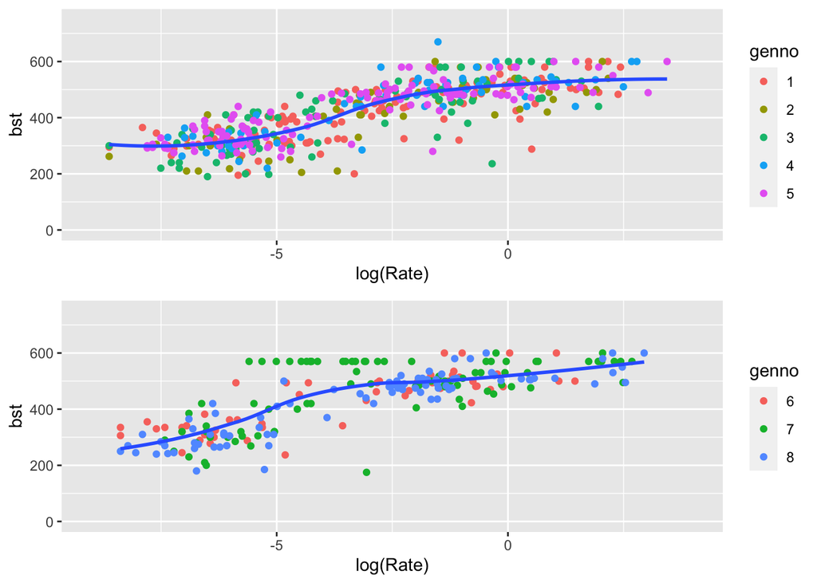

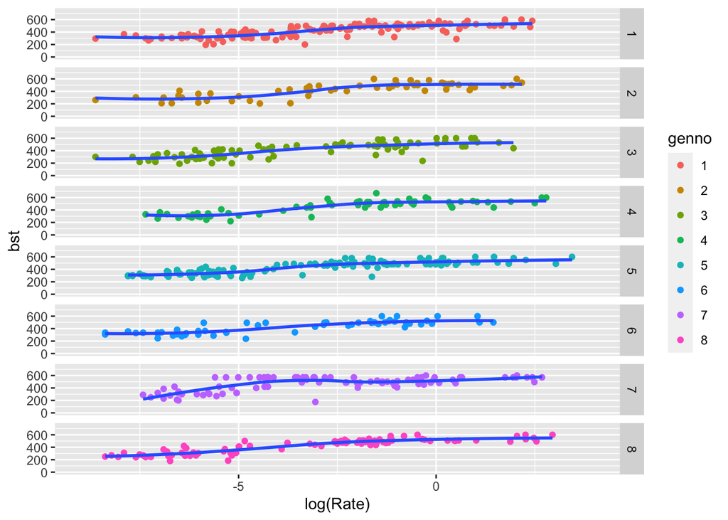

```
##
## Call:
## lm(formula = log(Rate) ~ bst, data = logdex)
##
## Coefficients:
## (Intercept)          bst
##   -11.96208      0.02077
```

```
##
## Call:
## lm(formula = log(Rate) ~ bst + generation, data = logdex)
##
## Coefficients:
## (Intercept)          bst   generation
##   -11.58355      0.02095     -0.10518
```

```
## Analysis of Variance Table
##
## Model 1: log(Rate) ~ bst + generation
## Model 2: log(Rate) ~ bst
##   Res.Df    RSS Df Sum of Sq      F    Pr(>F)
## 1    691 2045.4
## 2    692 2088.8 -1   -43.432 14.672 0.0001395 ***
## ---
## Signif. codes:  0 '***' 0.001 '**' 0.01 '*' 0.05 '.' 0.1 ' ' 1
```

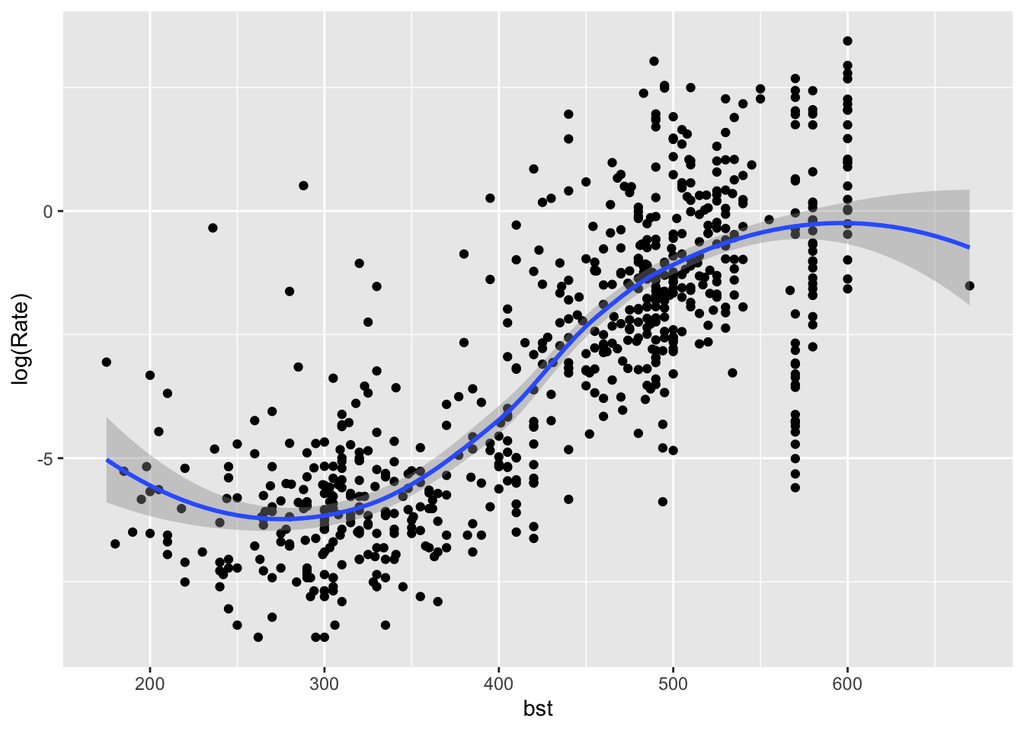

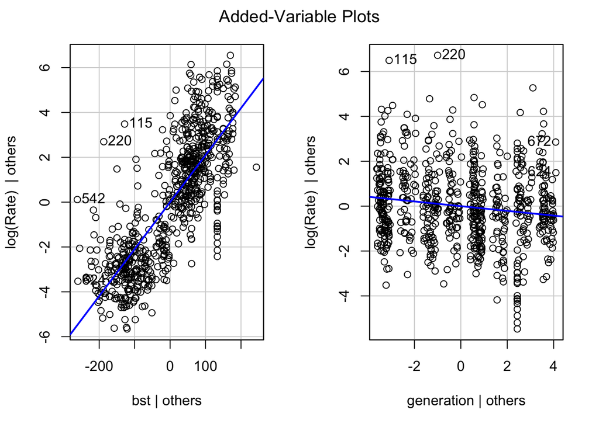

# APPENDIX

```
##
## Call:
## lm(formula = log(Rate) ~ bst + generation, data = logdex)
##
## Residuals:
##     Min      1Q  Median      3Q     Max
## -5.2157 -1.1474 -0.0783  0.9906  6.6141
##
## Coefficients:
##               Estimate Std. Error t value Pr(>|t|)
## (Intercept) -1.158e+01  2.875e-01  -40.29  < 2e-16 ***
## bst          2.095e-02  6.143e-04   34.10  < 2e-16 ***
## generation  -1.052e-01  2.746e-02   -3.83  0.00014 ***
## ---
## Signif. codes:  0 '***' 0.001 '**' 0.01 '*' 0.05 '.' 0.1 ' ' 1
##
## Residual standard error: 1.72 on 691 degrees of freedom
## Multiple R-squared:  0.6275, Adjusted R-squared:  0.6264
## F-statistic: 582.1 on 2 and 691 DF,  p-value: < 2.2e-16
```

```
##
## Call:
## lm(formula = log(Rate) ~ bst, data = logdex)
##
## Residuals:
##     Min      1Q  Median      3Q     Max
## -5.4716 -1.1289 -0.0938  1.0293  6.7192
##
## Coefficients:
##               Estimate Std. Error t value Pr(>|t|)
## (Intercept) -1.196e+01  2.726e-01  -43.88   <2e-16 ***
## bst          2.077e-02  6.185e-04   33.57   <2e-16 ***
## ---
## Signif. codes:  0 '***' 0.001 '**' 0.01 '*' 0.05 '.' 0.1 ' ' 1
##
## Residual standard error: 1.737 on 692 degrees of freedom
## Multiple R-squared:  0.6196, Adjusted R-squared:  0.6191
## F-statistic:  1127 on 1 and 692 DF,  p-value: < 2.2e-16
```

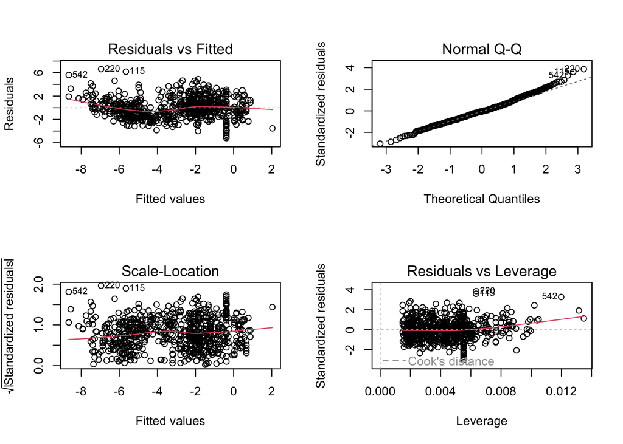

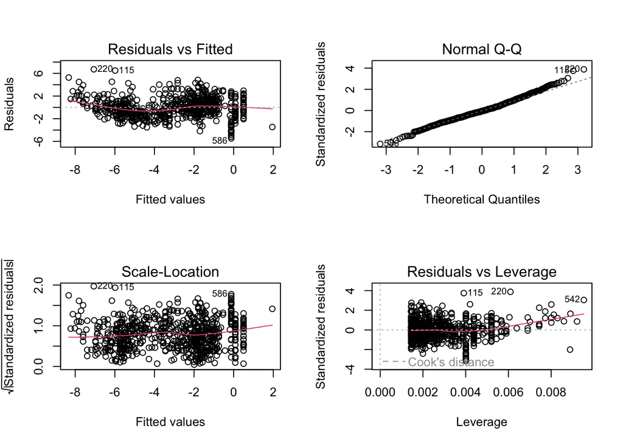

[output not shown]

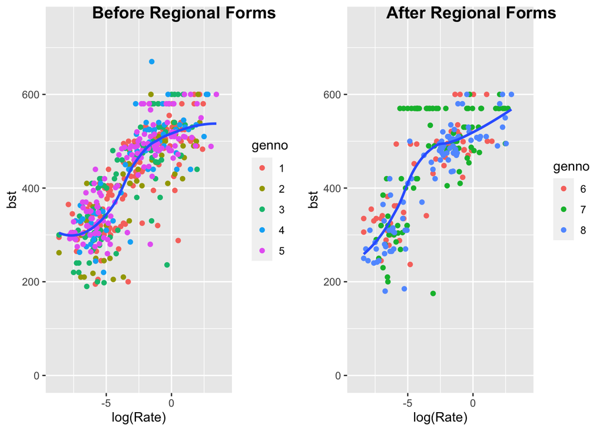

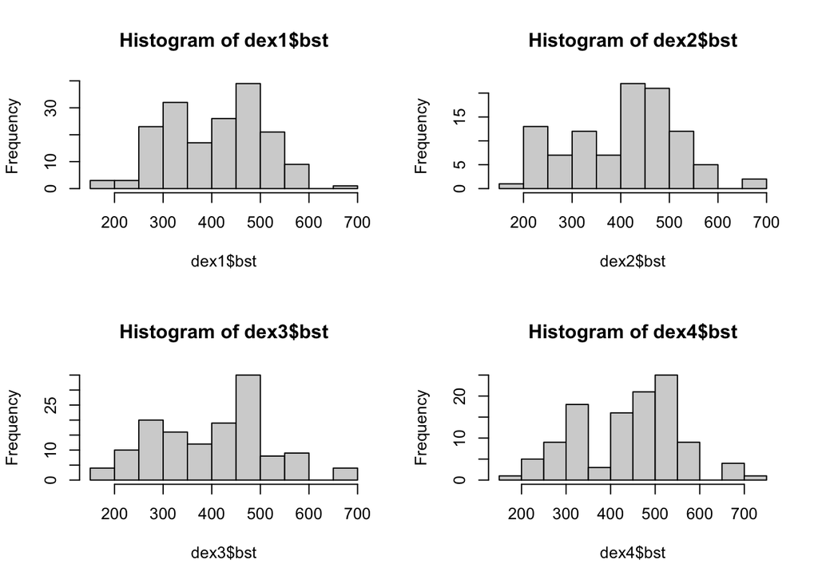

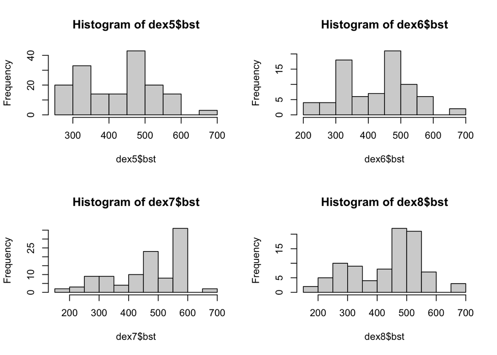